# Damage Analysis of U.S. Weather Events

## Synopsis

The goal of this analysis is to answer two questions related to the degree of damage caused by weather events in the United States.

First, which types of events are most harmful with respect to population health?  
Second, which types of events have the greatest economic consequences?

To answer these questions, I analyzed a public dataset from the U.S. National Oceanic and Atmospheric Administration’s storm database.

This database tracks characteristics of major storms and weather events in the United States, including when and where they occur, as well as estimates of any fatalities, injuries, property damage, and crop damage.

The product of this analysis is a list of the most damaging weather events evaluated by fatalities, injuries, estimated property damage, and estimated crop damage.

All meaningful analysis is described below, as a set of instructions that can be used to reproduce the results.

## Data Processing

Download the publically available dataset: https://d396qusza40orc.cloudfront.net/repdata%2Fdata%2FStormData.csv.bz2  
Save the file in the working directory in a ‘data’ subdirectory.

```r
download.file("https://d396qusza40orc.cloudfront.net/repdata%2Fdata%2FStormData.csv.bz2", destfile = "./data/repdata data StormData.csv.bz2")
```

Read the file into a dataframe.

```r
df <- read.csv("./data/repdata data Stormdata.csv.bz2", header = TRUE)
```

Determine the structure of the variables, and select the relevant variables to use in the analysis.

```r
str(df)
```

```
## 'data.frame':    902297 obs. of  37 variables:
##  $ STATE__   : num  1 1 1 1 1 1 1 1 1 1 ...
##  $ BGN_DATE  : Factor w/ 16335 levels "1/1/1966 0:00:00",..: 6523 6523 4242 11116 2224 2224 2260 383 3980 3980 ...
##  $ BGN_TIME  : Factor w/ 3608 levels "00:00:00 AM",..: 272 287 2705 1683 2584 3186 242 1683 3186 3186 ...
##  $ TIME_ZONE : Factor w/ 22 levels "ADT","AKS","AST",..: 7 7 7 7 7 7 7 7 7 7 ...
##  $ COUNTY    : num  97 3 57 89 43 77 9 123 125 57 ...
##  $ COUNTYNAME: Factor w/ 29601 levels "","5NM E OF MACKINAC BRIDGE TO PRESQUE ISLE LT MI",..: 13513 1873 4598 10592 4372 10094 1973 23873 24418 4598 ...
##  $ STATE     : Factor w/ 72 levels "AK","AL","AM",..: 2 2 2 2 2 2 2 2 2 2 ...
##  $ EVTYPE    : Factor w/ 985 levels "   HIGH SURF ADVISORY",..: 834 834 834 834 834 834 834 834 834 834 ...
##  $ BGN_RANGE : num  0 0 0 0 0 0 0 0 0 0 ...
##  $ BGN_AZI   : Factor w/ 35 levels "","  N"," NW",..: 1 1 1 1 1 1 1 1 1 1 ...
##  $ BGN_LOCATI: Factor w/ 54429 levels "","- 1 N Albion",..: 1 1 1 1 1 1 1 1 1 1 ...
##  $ END_DATE  : Factor w/ 6663 levels "","1/1/1993 0:00:00",..: 1 1 1 1 1 1 1 1 1 1 ...
##  $ END_TIME  : Factor w/ 3647 levels ""," 0900CST",..: 1 1 1 1 1 1 1 1 1 1 ...
##  $ COUNTY_END: num  0 0 0 0 0 0 0 0 0 0 ...
```

[output cut: 23 more lines]

Most of the variables are explained by their titles.

Use unique() to get a list of unique values for a single variable. This helps to clarify data when the title is difficult to decipher.

Event types are stored in the EVTYPE variable. There are 985 unique values. Look at a sample of 50 to get a sense for the data.

```r
length(unique(df$EVTYPE))
```

```
## [1] 985
```

```r
head(unique(df$EVTYPE), 50)
```

```
##  [1] TORNADO                        TSTM WIND
##  [3] HAIL                           FREEZING RAIN
##  [5] SNOW                           ICE STORM/FLASH FLOOD
##  [7] SNOW/ICE                       WINTER STORM
##  [9] HURRICANE OPAL/HIGH WINDS      THUNDERSTORM WINDS
## [11] RECORD COLD                    HURRICANE ERIN
## [13] HURRICANE OPAL                 HEAVY RAIN
## [15] LIGHTNING                      THUNDERSTORM WIND
## [17] DENSE FOG                      RIP CURRENT
## [19] THUNDERSTORM WINS              FLASH FLOOD
## [21] FLASH FLOODING                 HIGH WINDS
## [23] FUNNEL CLOUD                   TORNADO F0
## [25] THUNDERSTORM WINDS LIGHTNING   THUNDERSTORM WINDS/HAIL
## [27] HEAT                           WIND
## [29] LIGHTING                       HEAVY RAINS
## [31] LIGHTNING AND HEAVY RAIN       FUNNEL
## [33] WALL CLOUD                     FLOODING
## [35] THUNDERSTORM WINDS HAIL        FLOOD
## [37] COLD                           HEAVY RAIN/LIGHTNING
## [39] FLASH FLOODING/THUNDERSTORM WI WALL CLOUD/FUNNEL CLOUD
## [41] THUNDERSTORM                   WATERSPOUT
## [43] EXTREME COLD                   HAIL 1.75)
## [45] LIGHTNING/HEAVY RAIN           HIGH WIND
## [47] BLIZZARD                       BLIZZARD WEATHER
## [49] WIND CHILL                     BREAKUP FLOODING
## 985 Levels:    HIGH SURF ADVISORY  COASTAL FLOOD ... WND
```

Two variables relate directly to population health: FATALITIES and INJURIES.

```r
class(df$FATALITIES)
```

```
## [1] "numeric"
```

```r
range(df$FATALITIES)
```

```
## [1]   0 583
```

```r
class(df$INJURIES)
```

```
## [1] "numeric"
```

```r
range(df$INJURIES)
```

```
## [1]    0 1700
```

Four variables relate directly to economic impact: PROPDMG, PROPDMGEXP, CROPDMG, CROPDMGEXP

Check to see if there are any NA values in any of the columns of interest. Do so using complete.cases() on a subset of columns. Then convert the logical vector into numeric values (negated, so 0 is for complete, 1 for incomplete), and sum the results. A sum of 0 indicates no incomplete cases.

```r
sum(as.numeric(!complete.cases(df[,c("FATALITIES","INJURIES","PROPDMG","CROPDMG","PROPDMGEXP","CROPDMGEXP","EVTYPE")])))
```

```
## [1] 0
```

All cases are complete. No need to worry about NAs in calculations (yet). Continue to explore the column variables.

PROPDMG and CROPDMG are numeric variables.

```r
class(df$PROPDMG)
```

```
## [1] "numeric"
```

```r
range(df$PROPDMG)
```

```
## [1]    0 5000
```

```r
class(df$CROPDMG)
```

```
## [1] "numeric"
```

```r
range(df$CROPDMG)
```

```
## [1]   0 990
```

PROPDMGEXP and CROPDMGEXP are factor variables.

```r
class(df$PROPDMGEXP)
```

```
## [1] "factor"
```

```r
class(df$CROPDMGEXP)
```

```
## [1] "factor"
```

Use unique() to see the factor levels in use for PROPDMGEXP and CROPDMGEXP.

```r
unique(df$PROPDMGEXP)
```

```
##  [1] K M   B m + 0 5 6 ? 4 2 3 h 7 H - 1 8
## Levels:  - ? + 0 1 2 3 4 5 6 7 8 B h H K m M
```

```r
unique(df$CROPDMGEXP)
```

```
## [1]   M K m B ? 0 k 2
## Levels:  ? 0 2 B k K m M
```

There is not a clear explanation on how to interpret these factor variables. This analysis ASSUMES that EXP stands for exponent, and these are meant to act as multipliers to the PROPDMG and CROPDMG columns.

### Data processing for property damage.

This analysis focuses on the most damaging events. Remove rows with zero-values for the sake of performance.

```r
    nzdf.p <- subset(df, df$PROPDMG > 0)
```

```r
nzdf.p$PROPDMGMULT = 0
for (i in seq(length(nzdf.p$REFNUM))) {
        if (is.numeric(nzdf.p[i, "PROPDMGEXP"]) == FALSE) {
            nzdf.p[i, "PROPDMGEXP"] = 0
        }
        else if (toupper(nzdf.p[i, "PROPDMGEXP"]) == "H") {
            nzdf.p[i, "PROPDMGEXP"] = 2
        }
        else if (toupper(nzdf.p[i, "PROPDMGEXP"]) == "K") {
            nzdf.p[i, "PROPDMGEXP"] = 3
        }
        else if (toupper(nzdf.p[i, "PROPDMGEXP"]) == "M") {
            nzdf.p[i, "PROPDMGEXP"] = 6
        }
        else if (toupper(nzdf.p[i, "PROPDMGEXP"]) == "B") {
            nzdf.p[i, "PROPDMGEXP"] = 9
        }
        nzdf.p[i, "PROPDMGMULT"] = nzdf.p[i, "PROPDMG"] * 10^as.numeric(as.character(nzdf.p[i, "PROPDMGEXP"]))
    }
```

Sum the total damage per event, measured by propery damage.

```r
    totals.p <- tapply(nzdf.p$PROPDMGMULT, nzdf.p$EVTYPE, sum)
```

Check for NAs in this totals list.

```r
    length(totals.p[is.na(totals.p)])
```

```
## [1] 579
```

NAs exist even though there were no incomplete cases in the dataframe. This is because the EVTYPE column is a factor variable that kept all 985 levels from the original dataset. tapply() attempts to sum over all of the factor levels, but many of them no longer have associated values in the current subset.

Remove NAs.

```r
    full_totals.p <- totals.p[!is.na(totals.p)]
```

Order the totals.

```r
ordered_totals.p <- sort(full_totals.p, decreasing = TRUE)
```

### Data processing for crop damage.

This analysis focuses on the most damaging events. Remove rows with zero-values for the sake of performance.

```r
    nzdf.c <- subset(df, df$CROPDMG > 0)
```

```r
nzdf.c$CROPDMGMULT = 0
for (i in seq(length(nzdf.c$REFNUM))) {
        if (is.numeric(nzdf.c[i, "CROPDMGEXP"]) == FALSE) {
            nzdf.c[i, "CROPDMGEXP"] = 0
        }
        else if (toupper(nzdf.c[i, "CROPDMGEXP"]) == "H") {
            nzdf.c[i, "CROPDMGEXP"] = 2
        }
        else if (toupper(nzdf.c[i, "CROPDMGEXP"]) == "K") {
            nzdf.c[i, "CROPDMGEXP"] = 3
        }
        else if (toupper(nzdf.c[i, "CROPDMGEXP"]) == "M") {
            nzdf.c[i, "CROPDMGEXP"] = 6
        }
        else if (toupper(nzdf.c[i, "CROPDMGEXP"]) == "B") {
            nzdf.c[i, "CROPDMGEXP"] = 9
        }
        nzdf.c[i, "CROPDMGMULT"] = nzdf.c[i, "CROPDMG"] * 10^as.numeric(as.character(nzdf.c[i, "CROPDMGEXP"]))
    }
```

Sum the total damage per event, measured by crop damage.

```r
    totals.c <- tapply(nzdf.c$CROPDMGMULT, nzdf.c$EVTYPE, sum)
```

Check for NAs in this totals list.

```r
    length(totals.c[is.na(totals.c)])
```

```
## [1] 849
```

NAs exist even though there were no incomplete cases in the dataframe. This is because the EVTYPE column is a factor variable that kept all 985 levels from the original dataset. tapply() attempts to sum over all of the factor levels, but many of them no longer have associated values in the current subset.

Remove NAs.

```r
    full_totals.c <- totals.c[!is.na(totals.c)]
```

Order the totals.

```r
ordered_totals.c <- sort(full_totals.c, decreasing = TRUE)
```

### Data processing for fatalities.

This analysis focuses on the most damaging events. Remove rows with zero-values for the sake of performance.

```r
    nzdf.f <- subset(df, df$FATALITIES > 0)
```

Sum the total damage per event, measured by fatalities.

```r
    totals.f <- tapply(nzdf.f$FATALITIES, nzdf.f$EVTYPE, sum)
```

Check for NAs in this totals list.

```r
    length(totals.f[is.na(totals.f)])
```

```
## [1] 817
```

NAs exist even though there were no incomplete cases in the dataframe. This is because the EVTYPE column is a factor variable that kept all 985 levels from the original dataset. tapply() attempts to sum over all of the factor levels, but many of them no longer have associated values in the current subset.

Remove NAs.

```r
    full_totals.f <- totals.f[!is.na(totals.f)]
```

Order the totals.

```r
ordered_totals.f <- sort(full_totals.f, decreasing = TRUE)
```

### Data processing for injuries.

This analysis focuses on the most damaging events. Remove rows with zero-values for the sake of performance.

```r
    nzdf.i <- subset(df, df$INJURIES > 0)
```

Sum the total damage per event, measured by injuries.

```r
    totals.i <- tapply(nzdf.i$INJURIES, nzdf.i$EVTYPE, sum)
```

Check for NAs in this totals list.

```r
    length(totals.i[is.na(totals.i)])
```

```
## [1] 827
```

NAs exist even though there were no incomplete cases in the dataframe. This is because the EVTYPE column is a factor variable that kept all 985 levels from the original dataset. tapply() attempts to sum over all of the factor levels, but many of them no longer have associated values in the current subset.

Remove NAs.

```r
    full_totals.i <- totals.i[!is.na(totals.i)]
```

Order the totals.

```r
ordered_totals.i <- sort(full_totals.i, decreasing = TRUE)
```

### Prepare cost data for a plot.

This analysis assumes that estimated property and cost data are measured with the same units (US Dollars), which allows them to be evaluated on a single plot.

So far, this analysis has created top ten lists for cost estimates.

Here are the top ten lists written out.

```r
    ordered_totals.p[1:10] # property
```

```
##            TORNADO        FLASH FLOOD          TSTM WIND
##          3212258.2          1420124.6          1335965.6
##              FLOOD  THUNDERSTORM WIND               HAIL
##           899938.5           876844.2           688693.4
##          LIGHTNING THUNDERSTORM WINDS          HIGH WIND
##           603351.8           446293.2           324731.6
##       WINTER STORM
##           132720.6
```

```r
    ordered_totals.c[1:10] # crop
```

```
##               HAIL        FLASH FLOOD              FLOOD
##          579596.28          179200.46          168037.88
##          TSTM WIND            TORNADO  THUNDERSTORM WIND
##          109202.60          100018.52           66791.45
##            DROUGHT THUNDERSTORM WINDS          HIGH WIND
##           33898.62           18684.93           17283.21
##         HEAVY RAIN
##           11122.80
```

Some events appear on both lists. In order to find the most damaging events, select the events that appear on both lists and observe their estimated costs. The intersect() function builds a list of entries that appear on both lists.

```r
# Use names() to find the names of the events that appear on both lists
inter <- intersect(names(ordered_totals.p[1:10]), names(ordered_totals.c[1:10]))
```

Create a sum of estimated property and crop cost for events that appear on both top ten lists.

```r
combined <- ordered_totals.p[inter] + ordered_totals.c[inter]
```

The data will be plotted in the Results section.

## Results

### Top ten most damaging event types measured by fatalities and injuries.

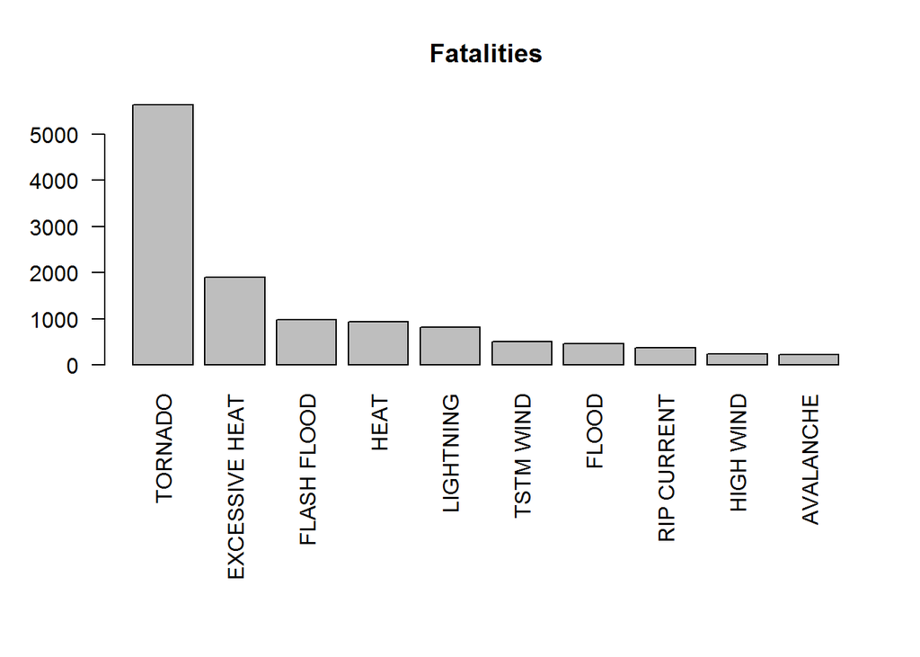

```r
    par(mar = c(11, 4, 4, 2))
    barplot(unlist(ordered_totals.f[1:10]), las = 2, main = "Fatalities")
```

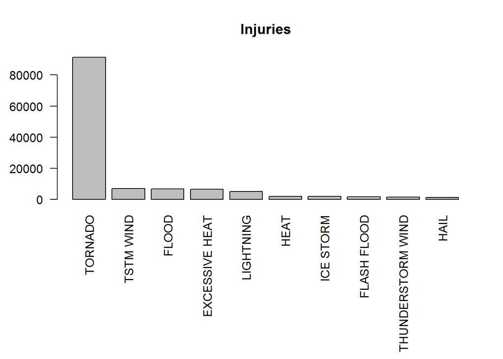

```r
    par(mar = c(11, 4, 4, 2))
    barplot(unlist(ordered_totals.i[1:10]), las = 2, main = "Injuries")
```

Here are the lists written out.

```r
    ordered_totals.f[1:10] # fatalities
```

```
##        TORNADO EXCESSIVE HEAT    FLASH FLOOD           HEAT      LIGHTNING
##           5633           1903            978            937            816
##      TSTM WIND          FLOOD    RIP CURRENT      HIGH WIND      AVALANCHE
##            504            470            368            248            224
```

```r
    ordered_totals.i[1:10] # injuries
```

```
##           TORNADO         TSTM WIND             FLOOD    EXCESSIVE HEAT
##             91346              6957              6789              6525
##         LIGHTNING              HEAT         ICE STORM       FLASH FLOOD
##              5230              2100              1975              1777
## THUNDERSTORM WIND              HAIL
##              1488              1361
```

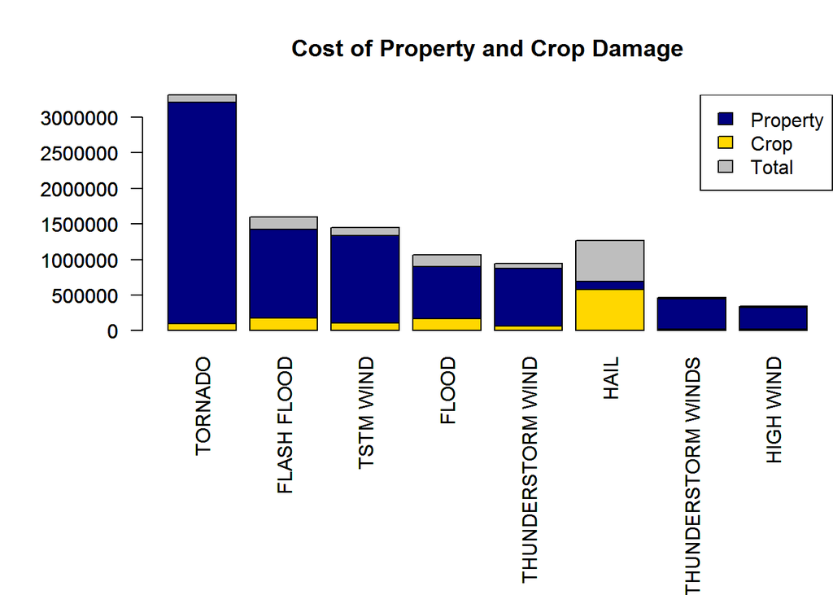

```r
par(mar = c(11, 6, 4, 0))
barplot(unlist(combined), las = 2, main = "Cost of Property and Crop Damage")
barplot(unlist(ordered_totals.p[inter]), las = 2, col = "navy", add = T)
barplot(unlist(ordered_totals.c[inter]), las = 2, col = "gold", add = T)
legend("topright", legend = c("Property", "Crop", "Total"), fill = c("navy", "gold", "gray"))
```

The results show the property damage, crop damage, and their sum.